# Risk Factor Analysis

## Outcome Variable

**Outcome Variable:** ever_stunted

## Predictor Variables

**Intervention Variable:** predfeed36

**Adjustment Set:**

- arm
- month
- brthmon
- W_mage
- meducyrs
- feducyrs
- hhwealth_quart
- hfoodsec
- W_mhtcm
- W_mwtkg
- W_mbmi
- vagbrth
- W_gagebrth
- W_birthwt
- W_birthlen
- W_nrooms
- W_nchldlt5
- W_parity
- impfloor
- impsan
- safeh20
- delta_W_mage
- delta_meducyrs
- delta_feducyrs
- delta_hhwealth_quart
- delta_hfoodsec
- delta_W_mhtcm
- delta_W_mwtkg
- delta_W_mbmi
- delta_vagbrth
- delta_W_gagebrth
- delta_W_birthwt
- delta_W_birthlen
- delta_W_nrooms
- delta_W_nchldlt5
- delta_W_parity
- delta_impfloor
- delta_impsan
- delta_safeh20

## Stratifying Variables

The analysis was stratified on these variable(s):

- agecat
- studyid
- country

## Data Summary

| agecat | studyid | country | predfeed36 | ever_stunted | n_cell | n |
| --- | --- | --- | --- | --- | --- | --- |
| 0-24 months (no birth st.) | EE | PAKISTAN | 1 | 0 | 0 | 6 |
| 0-24 months (no birth st.) | EE | PAKISTAN | 1 | 1 | 2 | 6 |
| 0-24 months (no birth st.) | EE | PAKISTAN | 0 | 0 | 2 | 6 |
| 0-24 months (no birth st.) | EE | PAKISTAN | 0 | 1 | 2 | 6 |
| 0-24 months (no birth st.) | GMS-Nepal | NEPAL | 1 | 0 | 132 | 443 |
| 0-24 months (no birth st.) | GMS-Nepal | NEPAL | 1 | 1 | 225 | 443 |
| 0-24 months (no birth st.) | GMS-Nepal | NEPAL | 0 | 0 | 22 | 443 |
| 0-24 months (no birth st.) | GMS-Nepal | NEPAL | 0 | 1 | 64 | 443 |
| 0-24 months (no birth st.) | JiVitA-3 | BANGLADESH | 1 | 0 | 4980 | 8764 |
| 0-24 months (no birth st.) | JiVitA-3 | BANGLADESH | 1 | 1 | 1855 | 8764 |
| 0-24 months (no birth st.) | JiVitA-3 | BANGLADESH | 0 | 0 | 1431 | 8764 |
| 0-24 months (no birth st.) | JiVitA-3 | BANGLADESH | 0 | 1 | 498 | 8764 |
| 0-24 months (no birth st.) | JiVitA-4 | BANGLADESH | 1 | 0 | 1502 | 3285 |
| 0-24 months (no birth st.) | JiVitA-4 | BANGLADESH | 1 | 1 | 1086 | 3285 |
| 0-24 months (no birth st.) | JiVitA-4 | BANGLADESH | 0 | 0 | 389 | 3285 |
| 0-24 months (no birth st.) | JiVitA-4 | BANGLADESH | 0 | 1 | 308 | 3285 |
| 0-24 months (no birth st.) | LCNI-5 | MALAWI | 1 | 0 | 18 | 175 |
| 0-24 months (no birth st.) | LCNI-5 | MALAWI | 1 | 1 | 12 | 175 |
| 0-24 months (no birth st.) | LCNI-5 | MALAWI | 0 | 0 | 83 | 175 |
| 0-24 months (no birth st.) | LCNI-5 | MALAWI | 0 | 1 | 62 | 175 |
| 0-24 months (no birth st.) | MAL-ED | BANGLADESH | 1 | 0 | 29 | 209 |
| 0-24 months (no birth st.) | MAL-ED | BANGLADESH | 1 | 1 | 45 | 209 |
| 0-24 months (no birth st.) | MAL-ED | BANGLADESH | 0 | 0 | 68 | 209 |
| 0-24 months (no birth st.) | MAL-ED | BANGLADESH | 0 | 1 | 67 | 209 |
| 0-24 months (no birth st.) | MAL-ED | BRAZIL | 1 | 0 | 18 | 195 |
| 0-24 months (no birth st.) | MAL-ED | BRAZIL | 1 | 1 | 3 | 195 |
| 0-24 months (no birth st.) | MAL-ED | BRAZIL | 0 | 0 | 146 | 195 |
| 0-24 months (no birth st.) | MAL-ED | BRAZIL | 0 | 1 | 28 | 195 |
| 0-24 months (no birth st.) | MAL-ED | INDIA | 1 | 0 | 5 | 201 |
| 0-24 months (no birth st.) | MAL-ED | INDIA | 1 | 1 | 10 | 201 |

[output cut: 126 more lines]

The following strata were considered:

- agecat: 0-24 months (no birth st.), studyid: EE, country: PAKISTAN
- agecat: 0-24 months (no birth st.), studyid: GMS-Nepal, country: NEPAL
- agecat: 0-24 months (no birth st.), studyid: JiVitA-3, country: BANGLADESH
- agecat: 0-24 months (no birth st.), studyid: JiVitA-4, country: BANGLADESH
- agecat: 0-24 months (no birth st.), studyid: LCNI-5, country: MALAWI
- agecat: 0-24 months (no birth st.), studyid: MAL-ED, country: BANGLADESH
- agecat: 0-24 months (no birth st.), studyid: MAL-ED, country: BRAZIL
- agecat: 0-24 months (no birth st.), studyid: MAL-ED, country: INDIA
- agecat: 0-24 months (no birth st.), studyid: MAL-ED, country: NEPAL
- agecat: 0-24 months (no birth st.), studyid: MAL-ED, country: PERU
- agecat: 0-24 months (no birth st.), studyid: MAL-ED, country: SOUTH AFRICA
- agecat: 0-24 months (no birth st.), studyid: MAL-ED, country: TANZANIA, UNITED REPUBLIC OF
- agecat: 0-24 months (no birth st.), studyid: SAS-FoodSuppl, country: INDIA
- agecat: 0-6 months (no birth st.), studyid: EE, country: PAKISTAN
- agecat: 0-6 months (no birth st.), studyid: GMS-Nepal, country: NEPAL
- agecat: 0-6 months (no birth st.), studyid: JiVitA-3, country: BANGLADESH
- agecat: 0-6 months (no birth st.), studyid: JiVitA-4, country: BANGLADESH
- agecat: 0-6 months (no birth st.), studyid: LCNI-5, country: MALAWI
- agecat: 0-6 months (no birth st.), studyid: MAL-ED, country: BANGLADESH
- agecat: 0-6 months (no birth st.), studyid: MAL-ED, country: BRAZIL
- agecat: 0-6 months (no birth st.), studyid: MAL-ED, country: INDIA
- agecat: 0-6 months (no birth st.), studyid: MAL-ED, country: NEPAL
- agecat: 0-6 months (no birth st.), studyid: MAL-ED, country: PERU
- agecat: 0-6 months (no birth st.), studyid: MAL-ED, country: SOUTH AFRICA
- agecat: 0-6 months (no birth st.), studyid: MAL-ED, country: TANZANIA, UNITED REPUBLIC OF
- agecat: 0-6 months (no birth st.), studyid: SAS-FoodSuppl, country: INDIA
- agecat: 6-24 months, studyid: EE, country: PAKISTAN
- agecat: 6-24 months, studyid: GMS-Nepal, country: NEPAL
- agecat: 6-24 months, studyid: JiVitA-3, country: BANGLADESH
- agecat: 6-24 months, studyid: JiVitA-4, country: BANGLADESH
- agecat: 6-24 months, studyid: LCNI-5, country: MALAWI
- agecat: 6-24 months, studyid: MAL-ED, country: BANGLADESH
- agecat: 6-24 months, studyid: MAL-ED, country: BRAZIL
- agecat: 6-24 months, studyid: MAL-ED, country: INDIA
- agecat: 6-24 months, studyid: MAL-ED, country: NEPAL
- agecat: 6-24 months, studyid: MAL-ED, country: PERU
- agecat: 6-24 months, studyid: MAL-ED, country: SOUTH AFRICA
- agecat: 6-24 months, studyid: MAL-ED, country: TANZANIA, UNITED REPUBLIC OF
- agecat: 6-24 months, studyid: SAS-FoodSuppl, country: INDIA

### Dropped Strata

Some strata were dropped due to rare outcomes:

- agecat: 0-24 months (no birth st.), studyid: EE, country: PAKISTAN
- agecat: 0-24 months (no birth st.), studyid: MAL-ED, country: BRAZIL
- agecat: 0-24 months (no birth st.), studyid: MAL-ED, country: NEPAL
- agecat: 0-24 months (no birth st.), studyid: MAL-ED, country: SOUTH AFRICA
- agecat: 0-24 months (no birth st.), studyid: MAL-ED, country: TANZANIA, UNITED REPUBLIC OF
- agecat: 0-24 months (no birth st.), studyid: SAS-FoodSuppl, country: INDIA
- agecat: 0-6 months (no birth st.), studyid: EE, country: PAKISTAN
- agecat: 0-6 months (no birth st.), studyid: LCNI-5, country: MALAWI
- agecat: 0-6 months (no birth st.), studyid: MAL-ED, country: BRAZIL
- agecat: 0-6 months (no birth st.), studyid: MAL-ED, country: INDIA
- agecat: 0-6 months (no birth st.), studyid: MAL-ED, country: NEPAL
- agecat: 0-6 months (no birth st.), studyid: MAL-ED, country: SOUTH AFRICA
- agecat: 0-6 months (no birth st.), studyid: MAL-ED, country: TANZANIA, UNITED REPUBLIC OF
- agecat: 0-6 months (no birth st.), studyid: SAS-FoodSuppl, country: INDIA
- agecat: 6-24 months, studyid: EE, country: PAKISTAN
- agecat: 6-24 months, studyid: MAL-ED, country: BRAZIL
- agecat: 6-24 months, studyid: MAL-ED, country: INDIA
- agecat: 6-24 months, studyid: MAL-ED, country: NEPAL
- agecat: 6-24 months, studyid: MAL-ED, country: SOUTH AFRICA
- agecat: 6-24 months, studyid: MAL-ED, country: TANZANIA, UNITED REPUBLIC OF
- agecat: 6-24 months, studyid: SAS-FoodSuppl, country: INDIA

## Methods Detail

We’re interested in the causal parameters $E[Y_a]$ for all values of $a \in \mathcal{A}$. These parameters represent the mean outcome if, possibly contrary to fact, we intervened to set all units to have $A=a$. Under the randomization and positivity assumptions, these are identified by the statistical parameters $\psi_a=E_W[E_{Y|A,W}(Y|A=a,W)]$. In addition, we’re interested in the mean of $Y$, $E[Y]$ under no intervention (the observed mean). We will estimate these parameters by using SuperLearner to fit the relevant likelihood factors – $E_{Y|A,W}(Y|A=a,W)$ and $p(A=a|W)$, and then updating our likelihood fit using a joint TMLE.

For unadjusted analyses ($W=\{\}$), initial likelihoods were estimated using Lrnr_glm to estimate the simple $E(Y|A)$ and Lrnr_mean to estimate $p(A)$. For adjusted analyses, a small library containing Lrnr_glmnet, Lrnr_xgboost, and Lrnr_mean was used.

Having estimated these parameters, we will then use the delta method to estimate relative risks and attributable risks relative to a prespecified baseline level of $A$.

# Results Detail

## Results Plots

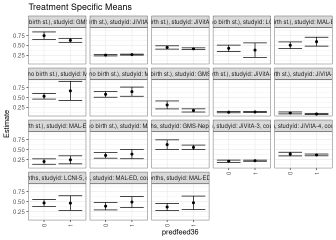

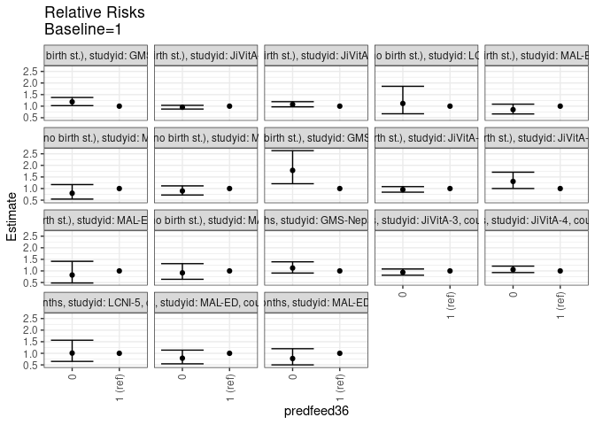

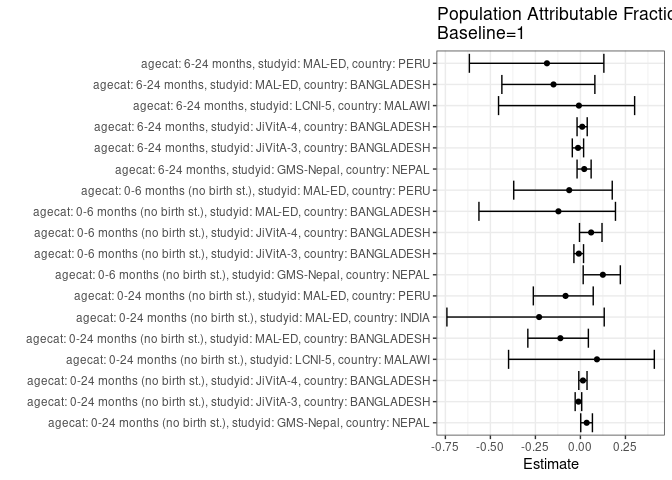

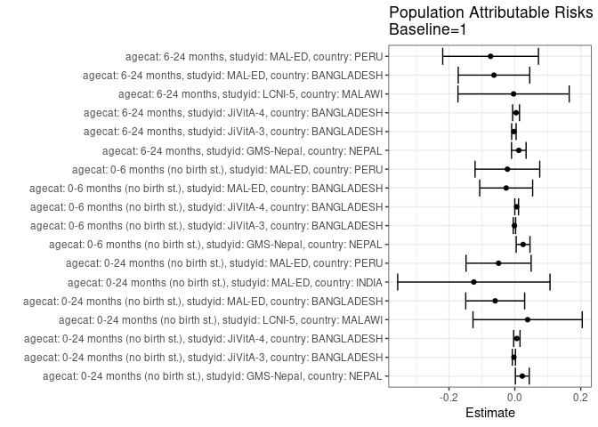

## Results Table

### Parameter: TSM

| agecat | studyid | country | intervention_level | baseline_level | estimate | ci_lower | ci_upper |
| --- | --- | --- | --- | --- | --- | --- | --- |
| 0-24 months (no birth st.) | GMS-Nepal | NEPAL | 1 | NA | 0.6296873 | 0.5794856 | 0.6798889 |
| 0-24 months (no birth st.) | GMS-Nepal | NEPAL | 0 | NA | 0.7469228 | 0.6538737 | 0.8399719 |
| 0-24 months (no birth st.) | JiVitA-3 | BANGLADESH | 1 | NA | 0.2713890 | 0.2590905 | 0.2836874 |
| 0-24 months (no birth st.) | JiVitA-3 | BANGLADESH | 0 | NA | 0.2583671 | 0.2385820 | 0.2781521 |
| 0-24 months (no birth st.) | JiVitA-4 | BANGLADESH | 1 | NA | 0.4183530 | 0.3959542 | 0.4407517 |
| 0-24 months (no birth st.) | JiVitA-4 | BANGLADESH | 0 | NA | 0.4504633 | 0.4089841 | 0.4919424 |
| 0-24 months (no birth st.) | LCNI-5 | MALAWI | 1 | NA | 0.3840268 | 0.2026451 | 0.5654086 |
| 0-24 months (no birth st.) | LCNI-5 | MALAWI | 0 | NA | 0.4287634 | 0.3478364 | 0.5096903 |
| 0-24 months (no birth st.) | MAL-ED | BANGLADESH | 1 | NA | 0.5955144 | 0.4838568 | 0.7071721 |
| 0-24 months (no birth st.) | MAL-ED | BANGLADESH | 0 | NA | 0.5059217 | 0.4223399 | 0.5895036 |
| 0-24 months (no birth st.) | MAL-ED | INDIA | 1 | NA | 0.6666667 | 0.4275118 | 0.9058215 |
| 0-24 months (no birth st.) | MAL-ED | INDIA | 0 | NA | 0.5322581 | 0.4603730 | 0.6041432 |
| 0-24 months (no birth st.) | MAL-ED | PERU | 1 | NA | 0.6469200 | 0.5317326 | 0.7621073 |
| 0-24 months (no birth st.) | MAL-ED | PERU | 0 | NA | 0.5800143 | 0.5076806 | 0.6523479 |
| 0-6 months (no birth st.) | GMS-Nepal | NEPAL | 1 | NA | 0.1758638 | 0.1361297 | 0.2155979 |
| 0-6 months (no birth st.) | GMS-Nepal | NEPAL | 0 | NA | 0.3137966 | 0.2139202 | 0.4136729 |
| 0-6 months (no birth st.) | JiVitA-3 | BANGLADESH | 1 | NA | 0.1375203 | 0.1283581 | 0.1466824 |
| 0-6 months (no birth st.) | JiVitA-3 | BANGLADESH | 0 | NA | 0.1313633 | 0.1170792 | 0.1456474 |
| 0-6 months (no birth st.) | JiVitA-4 | BANGLADESH | 1 | NA | 0.0869186 | 0.0732291 | 0.1006081 |
| 0-6 months (no birth st.) | JiVitA-4 | BANGLADESH | 0 | NA | 0.1136151 | 0.0889713 | 0.1382588 |
| 0-6 months (no birth st.) | MAL-ED | BANGLADESH | 1 | NA | 0.2416081 | 0.1407029 | 0.3425133 |
| 0-6 months (no birth st.) | MAL-ED | BANGLADESH | 0 | NA | 0.1988754 | 0.1311630 | 0.2665878 |
| 0-6 months (no birth st.) | MAL-ED | PERU | 1 | NA | 0.3850852 | 0.2691300 | 0.5010403 |
| 0-6 months (no birth st.) | MAL-ED | PERU | 0 | NA | 0.3529193 | 0.2830718 | 0.4227668 |
| 6-24 months | GMS-Nepal | NEPAL | 1 | NA | 0.5545596 | 0.4977014 | 0.6114178 |
| 6-24 months | GMS-Nepal | NEPAL | 0 | NA | 0.6236352 | 0.5045222 | 0.7427482 |
| 6-24 months | JiVitA-3 | BANGLADESH | 1 | NA | 0.2203685 | 0.2060358 | 0.2347013 |
| 6-24 months | JiVitA-3 | BANGLADESH | 0 | NA | 0.2069407 | 0.1789264 | 0.2349550 |
| 6-24 months | JiVitA-4 | BANGLADESH | 1 | NA | 0.3648773 | 0.3424536 | 0.3873010 |
| 6-24 months | JiVitA-4 | BANGLADESH | 0 | NA | 0.3862340 | 0.3402548 | 0.4322132 |
| 6-24 months | LCNI-5 | MALAWI | 1 | NA | 0.4606015 | 0.2762102 | 0.6449928 |
| 6-24 months | LCNI-5 | MALAWI | 0 | NA | 0.4645172 | 0.3799259 | 0.5491086 |
| 6-24 months | MAL-ED | BANGLADESH | 1 | NA | 0.4873802 | 0.3513068 | 0.6234537 |
| 6-24 months | MAL-ED | BANGLADESH | 0 | NA | 0.3841863 | 0.2900993 | 0.4782733 |
| 6-24 months | MAL-ED | PERU | 1 | NA | 0.4695614 | 0.3019885 | 0.6371343 |
| 6-24 months | MAL-ED | PERU | 0 | NA | 0.3635853 | 0.2735173 | 0.4536534 |

### Parameter: E(Y)

| agecat | studyid | country | intervention_level | baseline_level | estimate | ci_lower | ci_upper |
| --- | --- | --- | --- | --- | --- | --- | --- |
| 0-24 months (no birth st.) | GMS-Nepal | NEPAL | NA | NA | 0.6523702 | 0.6079743 | 0.6967661 |
| 0-24 months (no birth st.) | JiVitA-3 | BANGLADESH | NA | NA | 0.2684847 | 0.2575491 | 0.2794203 |
| 0-24 months (no birth st.) | JiVitA-4 | BANGLADESH | NA | NA | 0.4243531 | 0.4041458 | 0.4445604 |
| 0-24 months (no birth st.) | LCNI-5 | MALAWI | NA | NA | 0.4228571 | 0.3494545 | 0.4962598 |
| 0-24 months (no birth st.) | MAL-ED | BANGLADESH | NA | NA | 0.5358852 | 0.4681109 | 0.6036595 |
| 0-24 months (no birth st.) | MAL-ED | INDIA | NA | NA | 0.5422886 | 0.4732417 | 0.6113355 |
| 0-24 months (no birth st.) | MAL-ED | PERU | NA | NA | 0.5976096 | 0.5368226 | 0.6583966 |
| 0-6 months (no birth st.) | GMS-Nepal | NEPAL | NA | NA | 0.2009029 | 0.1635496 | 0.2382563 |
| 0-6 months (no birth st.) | JiVitA-3 | BANGLADESH | NA | NA | 0.1362858 | 0.1283472 | 0.1442245 |
| 0-6 months (no birth st.) | JiVitA-4 | BANGLADESH | NA | NA | 0.0924163 | 0.0803439 | 0.1044888 |
| 0-6 months (no birth st.) | MAL-ED | BANGLADESH | NA | NA | 0.2153110 | 0.1594513 | 0.2711707 |
| 0-6 months (no birth st.) | MAL-ED | PERU | NA | NA | 0.3625498 | 0.3029582 | 0.4221414 |
| 6-24 months | GMS-Nepal | NEPAL | NA | NA | 0.5665722 | 0.5148041 | 0.6183404 |
| 6-24 months | JiVitA-3 | BANGLADESH | NA | NA | 0.2175047 | 0.2040809 | 0.2309284 |
| 6-24 months | JiVitA-4 | BANGLADESH | NA | NA | 0.3685446 | 0.3480535 | 0.3890357 |
| 6-24 months | LCNI-5 | MALAWI | NA | NA | 0.4567901 | 0.3798457 | 0.5337346 |
| 6-24 months | MAL-ED | BANGLADESH | NA | NA | 0.4240506 | 0.3467471 | 0.5013542 |
| 6-24 months | MAL-ED | PERU | NA | NA | 0.3959732 | 0.3171819 | 0.4747644 |

### Parameter: RR

| agecat | studyid | country | intervention_level | baseline_level | estimate | ci_lower | ci_upper |
| --- | --- | --- | --- | --- | --- | --- | --- |
| 0-24 months (no birth st.) | GMS-Nepal | NEPAL | 1 | 1 | 1.0000000 | 1.0000000 | 1.000000 |
| 0-24 months (no birth st.) | GMS-Nepal | NEPAL | 0 | 1 | 1.1861806 | 1.0229459 | 1.375463 |
| 0-24 months (no birth st.) | JiVitA-3 | BANGLADESH | 1 | 1 | 1.0000000 | 1.0000000 | 1.000000 |
| 0-24 months (no birth st.) | JiVitA-3 | BANGLADESH | 0 | 1 | 0.9520177 | 0.8744421 | 1.036475 |
| 0-24 months (no birth st.) | JiVitA-4 | BANGLADESH | 1 | 1 | 1.0000000 | 1.0000000 | 1.000000 |
| 0-24 months (no birth st.) | JiVitA-4 | BANGLADESH | 0 | 1 | 1.0767541 | 0.9710329 | 1.193986 |
| 0-24 months (no birth st.) | LCNI-5 | MALAWI | 1 | 1 | 1.0000000 | 1.0000000 | 1.000000 |
| 0-24 months (no birth st.) | LCNI-5 | MALAWI | 0 | 1 | 1.1164934 | 0.6711908 | 1.857233 |
| 0-24 months (no birth st.) | MAL-ED | BANGLADESH | 1 | 1 | 1.0000000 | 1.0000000 | 1.000000 |
| 0-24 months (no birth st.) | MAL-ED | BANGLADESH | 0 | 1 | 0.8495541 | 0.6638095 | 1.087273 |
| 0-24 months (no birth st.) | MAL-ED | INDIA | 1 | 1 | 1.0000000 | 1.0000000 | 1.000000 |
| 0-24 months (no birth st.) | MAL-ED | INDIA | 0 | 1 | 0.7983871 | 0.5441800 | 1.171344 |
| 0-24 months (no birth st.) | MAL-ED | PERU | 1 | 1 | 1.0000000 | 1.0000000 | 1.000000 |
| 0-24 months (no birth st.) | MAL-ED | PERU | 0 | 1 | 0.8965781 | 0.7211546 | 1.114674 |
| 0-6 months (no birth st.) | GMS-Nepal | NEPAL | 1 | 1 | 1.0000000 | 1.0000000 | 1.000000 |
| 0-6 months (no birth st.) | GMS-Nepal | NEPAL | 0 | 1 | 1.7843156 | 1.2082965 | 2.634934 |
| 0-6 months (no birth st.) | JiVitA-3 | BANGLADESH | 1 | 1 | 1.0000000 | 1.0000000 | 1.000000 |
| 0-6 months (no birth st.) | JiVitA-3 | BANGLADESH | 0 | 1 | 0.9552288 | 0.8430671 | 1.082313 |
| 0-6 months (no birth st.) | JiVitA-4 | BANGLADESH | 1 | 1 | 1.0000000 | 1.0000000 | 1.000000 |
| 0-6 months (no birth st.) | JiVitA-4 | BANGLADESH | 0 | 1 | 1.3071429 | 1.0012283 | 1.706527 |
| 0-6 months (no birth st.) | MAL-ED | BANGLADESH | 1 | 1 | 1.0000000 | 1.0000000 | 1.000000 |
| 0-6 months (no birth st.) | MAL-ED | BANGLADESH | 0 | 1 | 0.8231322 | 0.4789892 | 1.414534 |
| 0-6 months (no birth st.) | MAL-ED | PERU | 1 | 1 | 1.0000000 | 1.0000000 | 1.000000 |
| 0-6 months (no birth st.) | MAL-ED | PERU | 0 | 1 | 0.9164708 | 0.6390469 | 1.314330 |
| 6-24 months | GMS-Nepal | NEPAL | 1 | 1 | 1.0000000 | 1.0000000 | 1.000000 |
| 6-24 months | GMS-Nepal | NEPAL | 0 | 1 | 1.1245593 | 0.9078001 | 1.393075 |
| 6-24 months | JiVitA-3 | BANGLADESH | 1 | 1 | 1.0000000 | 1.0000000 | 1.000000 |
| 6-24 months | JiVitA-3 | BANGLADESH | 0 | 1 | 0.9390663 | 0.8141552 | 1.083142 |
| 6-24 months | JiVitA-4 | BANGLADESH | 1 | 1 | 1.0000000 | 1.0000000 | 1.000000 |
| 6-24 months | JiVitA-4 | BANGLADESH | 0 | 1 | 1.0585312 | 0.9289494 | 1.206189 |
| 6-24 months | LCNI-5 | MALAWI | 1 | 1 | 1.0000000 | 1.0000000 | 1.000000 |
| 6-24 months | LCNI-5 | MALAWI | 0 | 1 | 1.0085013 | 0.6496243 | 1.565636 |
| 6-24 months | MAL-ED | BANGLADESH | 1 | 1 | 1.0000000 | 1.0000000 | 1.000000 |
| 6-24 months | MAL-ED | BANGLADESH | 0 | 1 | 0.7882681 | 0.5461758 | 1.137668 |
| 6-24 months | MAL-ED | PERU | 1 | 1 | 1.0000000 | 1.0000000 | 1.000000 |
| 6-24 months | MAL-ED | PERU | 0 | 1 | 0.7743084 | 0.5002755 | 1.198446 |

### Parameter: PAR

| agecat | studyid | country | intervention_level | baseline_level | estimate | ci_lower | ci_upper |
| --- | --- | --- | --- | --- | --- | --- | --- |
| 0-24 months (no birth st.) | GMS-Nepal | NEPAL | 1 | NA | 0.0226829 | 0.0016748 | 0.0436911 |
| 0-24 months (no birth st.) | JiVitA-3 | BANGLADESH | 1 | NA | -0.0029042 | -0.0077949 | 0.0019864 |
| 0-24 months (no birth st.) | JiVitA-4 | BANGLADESH | 1 | NA | 0.0060001 | -0.0036940 | 0.0156943 |
| 0-24 months (no birth st.) | LCNI-5 | MALAWI | 1 | NA | 0.0388303 | -0.1269655 | 0.2046262 |
| 0-24 months (no birth st.) | MAL-ED | BANGLADESH | 1 | NA | -0.0596293 | -0.1489961 | 0.0297376 |
| 0-24 months (no birth st.) | MAL-ED | INDIA | 1 | NA | -0.1243781 | -0.3555187 | 0.1067624 |
| 0-24 months (no birth st.) | MAL-ED | PERU | 1 | NA | -0.0493104 | -0.1481213 | 0.0495005 |
| 0-6 months (no birth st.) | GMS-Nepal | NEPAL | 1 | NA | 0.0250391 | 0.0041200 | 0.0459582 |
| 0-6 months (no birth st.) | JiVitA-3 | BANGLADESH | 1 | NA | -0.0012344 | -0.0048889 | 0.0024200 |
| 0-6 months (no birth st.) | JiVitA-4 | BANGLADESH | 1 | NA | 0.0054977 | -0.0001840 | 0.0111794 |
| 0-6 months (no birth st.) | MAL-ED | BANGLADESH | 1 | NA | -0.0262971 | -0.1066236 | 0.0540294 |
| 0-6 months (no birth st.) | MAL-ED | PERU | 1 | NA | -0.0225353 | -0.1206682 | 0.0755975 |
| 6-24 months | GMS-Nepal | NEPAL | 1 | NA | 0.0120126 | -0.0100524 | 0.0340776 |
| 6-24 months | JiVitA-3 | BANGLADESH | 1 | NA | -0.0028639 | -0.0096697 | 0.0039419 |
| 6-24 months | JiVitA-4 | BANGLADESH | 1 | NA | 0.0036673 | -0.0067393 | 0.0140740 |
| 6-24 months | LCNI-5 | MALAWI | 1 | NA | -0.0038114 | -0.1726071 | 0.1649842 |
| 6-24 months | MAL-ED | BANGLADESH | 1 | NA | -0.0633296 | -0.1718604 | 0.0452013 |
| 6-24 months | MAL-ED | PERU | 1 | NA | -0.0735883 | -0.2188885 | 0.0717119 |

### Parameter: PAF

| agecat | studyid | country | intervention_level | baseline_level | estimate | ci_lower | ci_upper |
| --- | --- | --- | --- | --- | --- | --- | --- |
| 0-24 months (no birth st.) | GMS-Nepal | NEPAL | 1 | NA | 0.0347700 | 0.0017934 | 0.0666572 |
| 0-24 months (no birth st.) | JiVitA-3 | BANGLADESH | 1 | NA | -0.0108172 | -0.0291710 | 0.0072094 |
| 0-24 months (no birth st.) | JiVitA-4 | BANGLADESH | 1 | NA | 0.0141395 | -0.0089809 | 0.0367301 |
| 0-24 months (no birth st.) | LCNI-5 | MALAWI | 1 | NA | 0.0918285 | -0.3990329 | 0.4104674 |
| 0-24 months (no birth st.) | MAL-ED | BANGLADESH | 1 | NA | -0.1112725 | -0.2920404 | 0.0442045 |
| 0-24 months (no birth st.) | MAL-ED | INDIA | 1 | NA | -0.2293578 | -0.7415161 | 0.1321811 |
| 0-24 months (no birth st.) | MAL-ED | PERU | 1 | NA | -0.0825127 | -0.2615548 | 0.0711194 |
| 0-6 months (no birth st.) | GMS-Nepal | NEPAL | 1 | NA | 0.1246328 | 0.0154077 | 0.2217412 |
| 0-6 months (no birth st.) | JiVitA-3 | BANGLADESH | 1 | NA | -0.0090578 | -0.0361663 | 0.0173415 |
| 0-6 months (no birth st.) | JiVitA-4 | BANGLADESH | 1 | NA | 0.0594885 | -0.0051278 | 0.1199508 |
| 0-6 months (no birth st.) | MAL-ED | BANGLADESH | 1 | NA | -0.1221354 | -0.5635848 | 0.1946789 |
| 0-6 months (no birth st.) | MAL-ED | PERU | 1 | NA | -0.0621579 | -0.3703977 | 0.1767503 |
| 6-24 months | GMS-Nepal | NEPAL | 1 | NA | 0.0212023 | -0.0186359 | 0.0594824 |
| 6-24 months | JiVitA-3 | BANGLADESH | 1 | NA | -0.0131670 | -0.0450530 | 0.0177462 |
| 6-24 months | JiVitA-4 | BANGLADESH | 1 | NA | 0.0099508 | -0.0186645 | 0.0377623 |
| 6-24 months | LCNI-5 | MALAWI | 1 | NA | -0.0083439 | -0.4547032 | 0.3010551 |
| 6-24 months | MAL-ED | BANGLADESH | 1 | NA | -0.1493444 | -0.4362836 | 0.0802704 |
| 6-24 months | MAL-ED | PERU | 1 | NA | -0.1858416 | -0.6167630 | 0.1302249 |